# Evaluation of health and economic costs of weather events in the United States

## Data Processing

First, the National Weather Service Storm Data was uploaded to R. Then data columns which were not relevant to the analysis were deleted. Next, the BGN_Date variable was converted into a POSIXlt object from which the ‘year’ was extracted and converted to a numeric variable.

```r
stormdata<-read.csv("repdata_data_StormData.csv.bz2")
slimdata<-stormdata[,c("BGN_DATE","EVTYPE","FATALITIES","INJURIES","PROPDMG","PROPDMGEXP","CROPDMG","CROPDMGEXP")]
slimdata$BGN_DATE<-as.POSIXlt(slimdata$BGN_DATE,format="%m/%d/%Y %H:%M:%S")
slimdata$year<-strftime(slimdata$BGN_DATE,format="%Y")
slimdata$year<-as.numeric(slimdata$year)
```

Initial exploration of the data revealed that only 20% of the data occurs before 1992. Examination of event type records up to 1992 showed that only the variables ‘STM WIND’, ‘HAIL’ and ‘TORNADOs’ were recorded.Starting in 1993, record numbers increased substantially, as did the types of events recorded.

```r
quantile(slimdata$year,seq(0,1,.2))
```

```
##   0%  20%  40%  60%  80% 100%
## 1950 1992 1999 2004 2008 2011
```

```r
summary(slimdata$EVTYPE[slimdata$year<=1992])
```

[output not shown]

[output cut: 45 more lines]

[output not shown]

Because the data up to 1992 did not appear complete, it was eliminated from the dataset to prevent a bias on ‘STM WIND’, ‘HAIL’ and ‘TORNADOs’ due to incomplete record keeping.

```r
slimdata2<-slimdata[slimdata$year>1992,]
```

In order to calculate total property damage and total crop damage, the ‘PROPDMGEXP’ and ‘CROPDMGEXP’ were converted into numeric values in a new column. It was assumed that the EXP columns indicated what power of 10 the DMG column should be raised to. Interpretation of the EXP column values can be seen in the code below:

```r
exp.conv<-function(x){if(x==""){1}
                       else {switch(x,
                                    '0'=1,
                                    '1'=10,
                                    '2'=100,'2'=100,'h'=100,'H'=100,
                                    '3'=1000,'k'=1000,'K'=1000,
                                    '4'=10^4,
                                    '5'=10^5,
                                    '6'=10^6,'m'=10^6,'M'=10^6,
                                    '7'=10^7,
                                    '8'=10^8,
                                    'B'=10^9,
                                    '-'=NA,'?'=NA,'+'=NA)
                       }
}

slimdata2$PROPDMGEXP<-as.character(slimdata2$PROPDMGEXP)
slimdata2$CROPDMGEXP<-as.character(slimdata2$CROPDMGEXP)

slimdata2$PROPDMGEXP.conv<-sapply(slimdata2$PROPDMGEXP,exp.conv)
slimdata2$CROPDMGEXP.conv<-sapply(slimdata2$CROPDMGEXP,exp.conv)
```

After the new numeric EXP column was created, it was multiplied by its respective DMG column to produce columns with the total property damage and total crop damage. Because the directions for Assignment 2 requested an evaluation of economic consequences, the total property damage and total crop damage were added together to give the total economic damage of each event.

```r
slimdata2$PROPDMG.num<-with(slimdata2,PROPDMG*PROPDMGEXP.conv)
slimdata2$CROPDMG.num<-with(slimdata2,CROPDMG*CROPDMGEXP.conv)

slimdata2$totaldmg<-with(slimdata2,PROPDMG.num+CROPDMG.num)
```

Next the total fatalities, injuries and total economic damage for each event type were calculated by summing the variables for each event type. In this analysis, fatalies and injuries were evaluated separately, since they have different implications on health impacts and therefore seemed inappropriate to combine into one variable.

```r
EVTYPE.sum<-as.data.frame(as.list(aggregate(cbind(FATALITIES,INJURIES,totaldmg)~EVTYPE,data=slimdata2,FUN=function(x) sum=sum(x,na.rm=TRUE))))
```

```r
EV.count<-nrow(EVTYPE.sum)
```

```r
fat.cut<-quantile(EVTYPE.sum$FATALITIES,.9)
inj.cut<-quantile(EVTYPE.sum$INJURIES,.9)
dmg.cut<-quantile(EVTYPE.sum$totaldmg,.9)
EVTYPE.short<-EVTYPE.sum[EVTYPE.sum$FATALITIES>fat.cut|EVTYPE.sum$INJURIES>inj.cut|EVTYPE.sum$FATALITIES>fat.cut,]
```

The total fatalities, injuries and economic damage among all events in the subset dataset were compared to totals in the complete dataset.

```r
per.fat<-round(sum(EVTYPE.short$FATALITIES)/sum(EVTYPE.sum$FATALITIES)*100,1)
per.inj<-round(sum(EVTYPE.short$INJURIES)/sum(EVTYPE.sum$INJURIES)*100,1)
per.econ<-round(sum(EVTYPE.short$totaldmg)/sum(EVTYPE.sum$totaldmg)*100,1)

subset.count<-nrow(EVTYPE.short)
```

Because 99.1%, 99.9% and 91.9% of the total fatalities, injuries and economic damage of the complete dataset were accounted for in the subset dataset and because the goal of the study is to identify the events with the largest impact, it was decided that the loss of the smallest observations in the datset would likely have a minimum impact on the analysis results. Subsetting the data reduced the number of events from 982 to 114, suggesting that many of the event types in the complete dataset had minimal health and economic effects.

Upon examination it was found that many weather event types were either the same or were similar enough to be lumped into the same category. Regular expressions with grepl were used to identify similar event types and assign them to a common variable. A few assignments require further explanation:

- Thunderstorms: thunderstorms and events caused by thunderstorms (hail, lightning, thunderstorm winds, microbursts, etc.) were all assigned to the same category.
- Tornados and waterspouts were put in the same category since they are the same event, but one is over land and one over water.
- Since typhoons, hurrincanes and tropical storms are similar events that vary maining in extremity and location, they were lumped into the same category. Storm surges were defined as flooding caused by hurricanes and tropical storms, so these were included in this group as well.

After all variables had been assigned a category, aggregate was used to calculate the new category totals for fatalities, injuries and economic damage.

```r
EVTYPE.short$EVTYPE<-as.character(EVTYPE.short$EVTYPE)
EVTYPE.short$category<-EVTYPE.short$EVTYPE

cold<-grepl("COLD|CHILL",EVTYPE.short$EVTYPE,perl=TRUE)
heat<-grepl("HEAT|WARM", EVTYPE.short$EVTYPE,perl=TRUE)
wind<-grepl("^WIND$|HIGH WIND|STRONG WIND|WIND DAMAGE|GUSTY WINDS", EVTYPE.short$EVTYPE,perl=TRUE)
winterweather<-grepl("SNOW|ICE|ICY|SLEET|FREEZING|BLIZZARD|LOW TEMPERATURE|GLAZE|WINTER|WINTRY|ICY|MIXED PRECIP",
                     EVTYPE.short$EVTYPE,perl=TRUE)
thunderstorms<-grepl("DRY MICROBURST|THUNDERSTORM|TSTM|HAIL|LIGHTNING", EVTYPE.short$EVTYPE,perl=TRUE)
tornado<-grepl("TORNADO|WATERSPOUT", EVTYPE.short$EVTYPE,perl=TRUE)
surf<-current<-grepl("SURF|HIGH SEAS|RIP CURRENT", EVTYPE.short$EVTYPE,perl=TRUE)
fire<-grepl("FIRE",EVTYPE.short$EVTYPE,perl=TRUE)
flood<-grepl("FLOOD|STREAM FLD",EVTYPE.short$EVTYPE,perl=TRUE)
duststorm<-grepl("DUST",EVTYPE.short$EVTYPE,perl=TRUE)
fog<-grepl("FOG",EVTYPE.short$EVTYPE,perl=TRUE)
heavyrain<-grepl("RAINFALL|HEAVY RAIN",EVTYPE.short$EVTYPE,perl=TRUE)
hurricane<-grepl("TYPHOON|HURRICANE|STORM SURGE|TROPICAL STORM",EVTYPE.short$EVTYPE,perl=TRUE)

EVTYPE.short$category[cold]<-"extreme cold"
EVTYPE.short$category[heat]<-"extreme heat"
EVTYPE.short$category[wind]<-"wind"
EVTYPE.short$category[winterweather]<-"winter weather"
EVTYPE.short$category[thunderstorms]<-"thunderstorms"
EVTYPE.short$category[tornado]<-"tornadoes"
EVTYPE.short$category[surf]<-"surf/current"
EVTYPE.short$category[fire]<-"wildfires"
EVTYPE.short$category[flood]<-"flooding"
EVTYPE.short$category[duststorm]<-"duststorms"
EVTYPE.short$category[hurricane]<-"hurricanes/tropical storms"
EVTYPE.short$category[fog]<-"fog"
EVTYPE.short$category[heavyrain]<-"heavy rain"

category.tot<-as.data.frame(as.list(aggregate(cbind(FATALITIES,INJURIES,totaldmg)~category,data=EVTYPE.short,FUN=function(x) sum=sum(x,na.rm=TRUE))))
```

## Results

### Events most harmful to human health

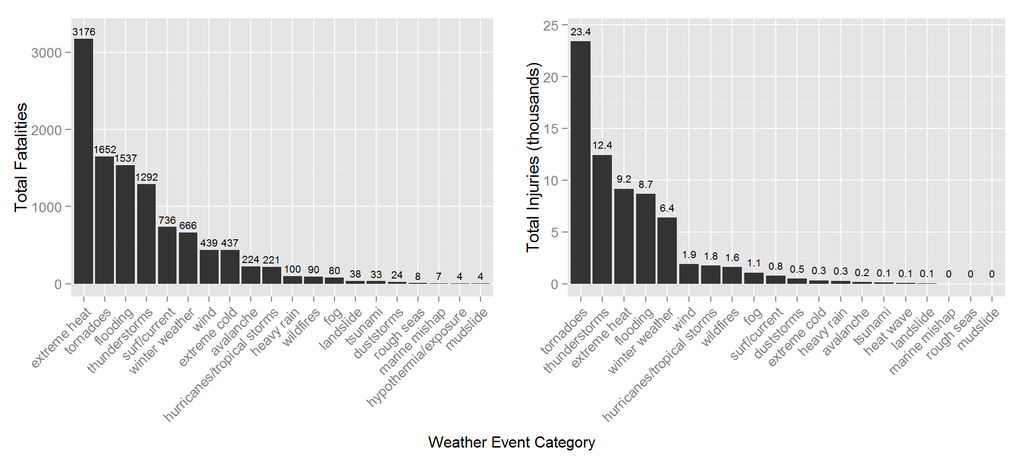

```r
library(ggplot2)
library(gridExtra)
category.tot$category<-tolower(category.tot$category)
category.tot$dmg.bil<-category.tot$totaldmg/10^9
category.tot$inj.thous<-category.tot$INJURIES/10^3
theme_set(theme_gray(base_size = 13))

fatalities.plot<-ggplot(data=category.tot[category.tot$FATALITIES>0,])+
        geom_bar(aes(x=reorder(category,-FATALITIES),y=FATALITIES),stat="identity")+
        geom_text(aes(x=reorder(category,-FATALITIES),y=FATALITIES+100,label=FATALITIES),size=2.75) +
        theme(axis.text.x = element_text(angle = 45,hjust=1))+
        ylab("Total Fatalities")+
        xlab("")

injuries.plot<-ggplot(data=category.tot[category.tot$inj.thous>0,])+
        geom_bar(aes(x=reorder(category,-inj.thous),y=inj.thous),stat="identity")+
        geom_text(aes(x=reorder(category,-inj.thous),y=inj.thous+1,label=round(inj.thous,1)),size=2.75)+
        theme(axis.text.x = element_text(angle = 45,hjust=1))+
        ylab("Total Injuries (thousands)")+
        xlab("")

grid.arrange(fatalities.plot,injuries.plot,ncol=2,sub=textGrob("Weather Event Category",gp=gpar(font=1),vjust=-1))
```

**Figure 1**. Total fatalities by weather event category from 1993 - 2011 (left) and total injuries by weather event category from 1993 - 2011 (right). Derived from National Weather Service Storm Data.

From Figure 1 it can be seen that extreme heat events are the leading cause of weather-related deaths in the U.S., with a total of 3,176 fatalities between 1993 - 2011. Tornadoes, flooding and thunderstorms were the next highest causes of death, with 1,652, 1,537 and 1,292 deaths, respectively. From Figure 1 we can also see that tornadoes were the leading cause of weather-related injuries between 1993 - 2011, causing 23,400 injuries. Thunderstorms, extreme heat and flooding were the next highest categories, resulting in 12,400, 9,200 and 8,700 injuries, respectively.

For both deaths and injuries, extreme heat, tornadoes, flooding and thunderstorms were top weather event categories. Therefore, this report concludes that these 4 events are the most harmful to human health.

### Events with greatest economic consequences

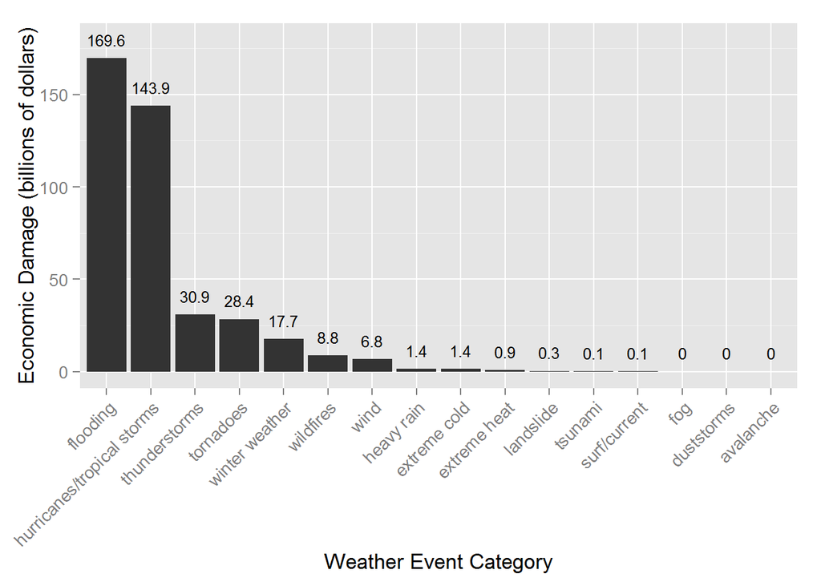

```r
ggplot(data=category.tot[category.tot$dmg.bil>0,])+
        geom_bar(aes(x=reorder(category,-dmg.bil),y=dmg.bil),stat="identity")+
        geom_text(aes(x=reorder(category,-dmg.bil),y=dmg.bil+10,label=round(dmg.bil,1)),size=3.5)+
        theme(axis.text.x = element_text(angle = 45,hjust=1))+
        xlab("Weather Event Category")+
        ylab("Economic Damage (billions of dollars)")
```

**Figure 2**. Total economic damage in billions of dollars by weather event category from 1993 - 2011. Derived from National Weather Service Storm Data.

From the data on economic damages we conclude that flooding and hurricanes/tropical storms have the greatest negative economic consequences.

## Conlcusions

- Extreme heat, tornadoes, flooding and thunderstorms caused the most fatalities and injuries. Therefore, this report concludes that these 4 events are the most harmful to human health.
- Flooding and hurricanes/tropical storms results in the the highest economic costs. Therefore, we conclude that flooding and hurricanes/tropical storms have the greatest negative economic consequences.